# Differential Expression - cell line drugging

## 2.5 Visualise differential expression results using a volcano plot

A volcano plot gives an idea about the number of genes that are differential in your dataset. If you do want you can also indicate the gene names. Try to play around with the code. Can you adapt the colors?

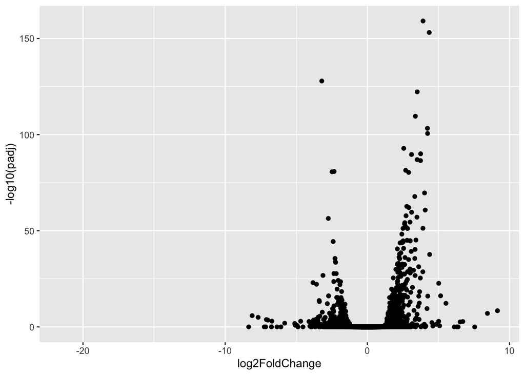

```r
### the ggplot solution
as.data.frame(res) %>%
  ggplot(aes(x=log2FoldChange,y=-log10(padj))) +
  geom_point()
```

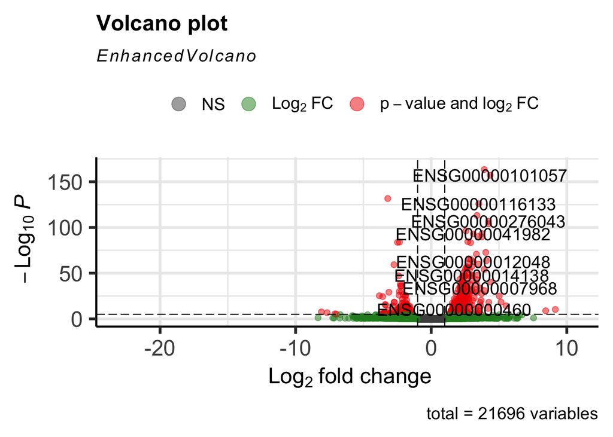

```r
### the enhanced volcanoplot solution
EnhancedVolcano(res,
    lab = rownames(res),
    x = 'log2FoldChange',
    y = 'pvalue')
```

# 3 Gene set enrichment analysis (GSEA)

Below I show how you can do GSEA using R.

Gene set enrichment analysis (GSEA) is a way to make sense out of the identified expression level differences between the tested sample groups.

GSEA compares expression in two biological states and determines if gene sets show significant, concordant change. GSEA determines if genes in a set generally increase or decrease in expression.

- GSEA uses data from all genes and not only the significantly differentially expressed.
- GSEA uses numeric fold change values. Thus, GSEA can identify pathways where lots of small changes not significant at the gene level add up to a significant change at the gene set level.
- GSEA compares only two states. .

## 3.1 Gene sets

What is a gene set? Two or more genes with similar function, structure, localization, or any other defining similarity.

Gene sets can be as general, e.g. cytosolic or mitochondrial, or highly specific as “up-regulated in blood vessel cells in response to wound in *Roy et al 2007*”. They can be defined by an individual research study (like the latter, often retrieved in a publication by differential expression analysis of specific processes), others are generally agreed upon knowledge formed from an entire body of literature (like the former). They also vary in the number of genes (2 to thousands), are not exclusive (one gene is in many gene sets), and many are redundant (transmembrane, membrane, lipid bilayer,…). Some are constructed by manual curating (literature review), while others are defined computationally (eg. transcription factor targets by binding site identification).

It is up to you, the researcher, to select what group of gene sets you want to test. Is definitely not “the more the better”, given the need for multiple testing correction. Carefully select the relevant gene sets you want to test this will decrease the correction you have to do for multiple testing.

### 3.1.1 Broad MSigDB gene sets

The Broad Institute has collated many useful gene sets in their Molecular Signatures Database ([MSigDB](https://www.gsea-msigdb.org/gsea/msigdb/collections.jsp)). Check this website. Can you find the Hallmark genesets?

Hallmark is the most general group and is usually where we start our analyses. It helps reduce the complexity of a large gene list down to easily understood terms. It also provides some context when looking at more specific gene sets as you can often group the other sets under a more general Hallmark term. However, because Hallmark is the most general, it is also the most incomplete with 50 gene sets representing just under 4400 genes.

Curated and gene ontology sets are more specific than Hallmark, though they contain sets with a range of specificities. They are particularly useful in adding details to a Hallmark term or defining testable hypotheses for follow-up experiments in the lab. They contain a lot more genes than Hallmark but many sets are redundant or overlapping. If there are many significant Hallmark terms, we often do not run these more specific sets as it gives too many results for interpretation. In contrast, when there are few significant Hallmark terms, these more granular gene sets may provide better insight.

There are several other sets in MSigDB. Some of these are too specific (individual studies) to be of use in your analyses (C2 chemical and genetic perturbations or C7 immunologic signatures) while others cover areas not relevant to the experimental design (C1 chromosome position, C3 gene regulation, C4/C6 cancer-oriented).

## 3.2 Get gene set data

We will access MSigDB from within R using the package `msigdbr`. It is important to update this package frequently as Broad continues to improve its gene set collections. First, we extract the lists of genes in Broad Hallmark terms from the package `msigdbr`. We format it as a data frame so we can use the `tidyverse`.

```r
### Hallmark
H <- as.data.frame(msigdbr(species = "Homo sapiens",
                           category = "H"))
```

However, `fgsea` needs the database as a list, not as a data frame. There are many ways we can accomplish this. Here is one using the `tidyverse`. Remember to select the gene ID column that matches your fold change data!

```r
H.ensembl.ls <- H %>%
  #Keep gene ID that match expression data gene ID
  select(gs_name, ensembl_gene) %>%
  #Collapse all genes in each gene set into 1 row each
  group_by(gs_name) %>%
  summarise(all.genes = list(unique(ensembl_gene))) %>%
  #Convert to list
  deframe()
```

## 3.3 Calculate fold change

GSEA orders the genes based on the mean gene expression fold change between the two groups that are compared. Thus, we retrieve it from the DE results in ‘res’.

`fgsea` requires a vector with decreasing fold changes (or list of vectors if you have multiple groups).

```r
results_df <- as.data.frame(res) %>%
  #Move gene IDs from rownames to a column
  rownames_to_column("ensembl_gene_id")
results_df_fcordered <- results_df %>% arrange(-log2FoldChange)
#Vector of mean fold change values
FC.vec <- results_df_fcordered$log2FoldChange
#Add gene annotation/names
#Importantly, since both columns come from the same data frame,
#we are confident that they are in the same order
names(FC.vec) <- results_df_fcordered$ensembl_gene_id
```

## 3.4 Run GSEA

Using our formatted data, we run GSEA. We also set the number of permutations to run with `nperm`, which determines how many times the algorithm is run to estimate p-values.

```r
gsea.H <- as.data.frame(fgseaSimple(pathways = H.ensembl.ls,
                                    stats = FC.vec,
                                    nperm = 4000,
                                    scoreType = "std"))
```

```
## Warning in preparePathwaysAndStats(pathways, stats, minSize, maxSize, gseaParam, : There are ties in the preranked stats (0.53% of the list).
## The order of those tied genes will be arbitrary, which may produce unexpected results.
```

You may also see a warning like

```
There were X pathways for which P-values were not calculated properly due to unbalanced gene-level statistic values
```

This occurs when `nperm` is not large enough to accurately estimate very small p-values (like those zeros in the gene linear model results!) If you see this error, try increasing `nperm` by orders of 10. Keep in mind that more permutations increase the time it takes to run GSEA. You may reach a point where it’s no longer worth it and should just fill in these NA with zeroes.

## 3.5 Extract GSEA results

GSEA outputs a data frame of results.

```r
class(gsea.H)
```

```
## [1] "data.frame"
```

This includes

```r
colnames(gsea.H)
```

```
## [1] "pathway"      "pval"         "padj"         "ES"           "NES"
## [6] "nMoreExtreme" "size"         "leadingEdge"
```

- pathway: Unique name for gene set
- pval: Significance
- padj: FDR adjusted significance
- ES: Enrichment score (same as Broad’s online GSEA program)
- NES: Enrichment score normalized to mean enrichment of random samples of the same size
- nMoreExtreme: Number of times a random gene set had a more extreme enrichment score value
- size: Total genes in gene set also found in fold change data
- leadingEdge: Leading edge genes that drive the enrichment,

## 3.6 Visualize significant GSEA

The most common visualization for GSEA is the enrichment or normalized enrichment score. Let’s plot `NES` for the subset of significant GSEA at FDR < 0.05. This is actually pretty strict for GSEA and people often go up to FDR < 0.2. Note that even with the more strict FDR, not every result makes sense, eg. the effect on the estrogen pathway as we are dealing with males.

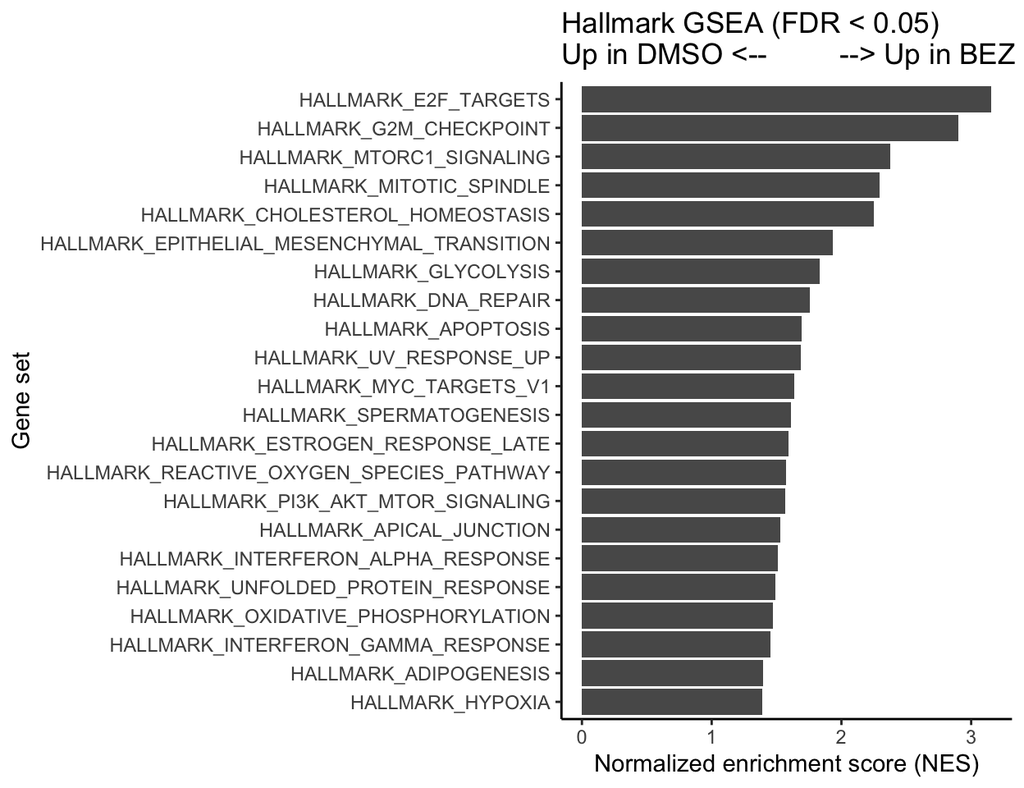

```r
gsea.H %>%
  filter(padj <= 0.05) %>%

ggplot(aes(x=reorder(pathway, NES), #Reorder gene sets by NES values
           y=NES)) +
  geom_col() +
  theme_classic() +
  #Force equal max min
  #Some more customization to pretty it up
  #Flip x and y so long labels can be read
  coord_flip() +
  #fix labels
  labs(y="Normalized enrichment score (NES)",
       x="Gene set",
       title = "Hallmark GSEA (FDR < 0.05)\nUp in DMSO <--         --> Up in BEZ")
```

We could also use visualisations implemented in the fgsea package itself.

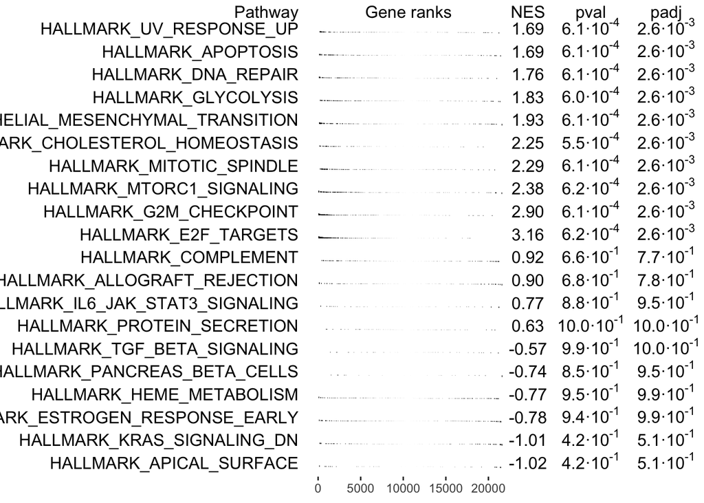

```r
topPathwaysUp <- gsea.H %>% arrange(NES) %>% top_n(10, NES) %>% select(pathway)
topPathwaysDown <- gsea.H %>% arrange(-NES) %>% top_n(10, -NES) %>% select(pathway)
topPathways <- c(topPathwaysUp$pathway, topPathwaysDown$pathway)
plotGseaTable(H.ensembl.ls[topPathways], FC.vec, gsea.H, render=TRUE)
```

We could also visualise the results of an individual gene set.

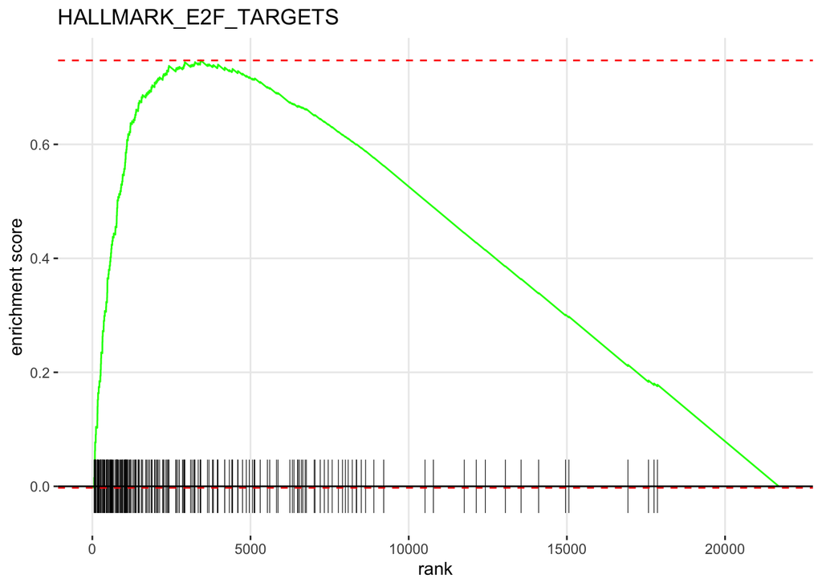

```r
plotEnrichment(H.ensembl.ls[["HALLMARK_E2F_TARGETS"]],
               FC.vec) + labs(title="HALLMARK_E2F_TARGETS")
```

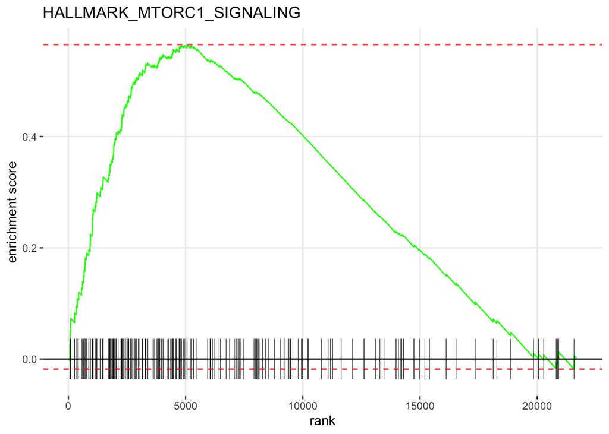

```r
plotEnrichment(H.ensembl.ls[["HALLMARK_MTORC1_SIGNALING"]],
               FC.vec) + labs(title="HALLMARK_MTORC1_SIGNALING")
```